# checkpoint1-P1 - Copy

```python
import pandas as pd
```

Read the dataset

```python
df = pd.read_csv(r'C:\Users\sagarkumar4\Documents\Datasets\User_product_purchase_final.csv')
df
```

|  | User_ID | Product_ID | City_Category | Stay_In_Current_City_Years | Marital_Status | Product_Category_1 | Product_Category_2 | Product_Category_3 | Purchase | Gender | Age | Occupation | City_Code | State_Code | Zip_Code | City_Name | State |
| --- | --- | --- | --- | --- | --- | --- | --- | --- | --- | --- | --- | --- | --- | --- | --- | --- | --- |
| 0 | 1000001 | P00069042 | A | 2 | 0 | 3 | NaN | NaN | 8370 | F | 0-17 | 10 | C259 | S16 | 42420 | Henderson | Kentucky |
| 1 | 1000001 | P00248942 | A | 2 | 0 | 1 | 6.0 | 14.0 | 15200 | F | 0-17 | 10 | C259 | S16 | 42420 | Henderson | Kentucky |
| 2 | 1000001 | P00087842 | A | 2 | 0 | 12 | NaN | NaN | 1422 | F | 0-17 | 10 | C259 | S16 | 42420 | Henderson | Kentucky |
| 3 | 1000001 | P00085442 | A | 2 | 0 | 12 | 14.0 | NaN | 1057 | F | 0-17 | 10 | C259 | S16 | 42420 | Henderson | Kentucky |
| 4 | 1000002 | P00285442 | C | 4+ | 0 | 8 | NaN | NaN | 7969 | M | 55+ | 16 | C259 | S16 | 42420 | Henderson | Kentucky |
| ... | ... | ... | ... | ... | ... | ... | ... | ... | ... | ... | ... | ... | ... | ... | ... | ... | ... |
| 550063 | 1006033 | P00372445 | B | 1 | 1 | 20 | NaN | NaN | 368 | M | 51-55 | 13 | C60 | S04 | 90712 | Lakewood | California |
| 550064 | 1006035 | P00375436 | C | 3 | 0 | 20 | NaN | NaN | 371 | F | 26-35 | 1 | C64 | S04 | 90049 | Los Angeles | California |
| 550065 | 1006036 | P00375436 | B | 4+ | 1 | 20 | NaN | NaN | 137 | F | 26-35 | 15 | C522 | S42 | 77036 | Houston | Texas |
| 550066 | 1006038 | P00375436 | C | 2 | 0 | 20 | NaN | NaN | 365 | F | 55+ | 1 | C235 | S20 | 1841 | Lawrence | Massachusetts |
| 550067 | 1006039 | P00371644 | B | 4+ | 1 | 20 | NaN | NaN | 490 | F | 46-50 | 0 | C390 | S31 | 10011 | New York City | New York |

550068 rows × 17 columns

Grouping the data according to the user ID

```python
df1 = df.groupby(['User_ID']).sum()
df1
```

| User_ID | Marital_Status | Product_Category_1 | Product_Category_2 | Product_Category_3 | Purchase | Occupation | Zip_Code |
| --- | --- | --- | --- | --- | --- | --- | --- |
| 1000001 | 0 | 213 | 132.0 | 148.0 | 334093 | 350 | 1484700 |
| 1000002 | 0 | 354 | 539.0 | 359.0 | 810472 | 1232 | 3266340 |
| 1000003 | 0 | 93 | 117.0 | 148.0 | 341635 | 435 | 2611044 |
| 1000004 | 14 | 33 | 102.0 | 127.0 | 206468 | 98 | 466354 |
| 1000005 | 106 | 659 | 642.0 | 207.0 | 821001 | 2120 | 3530966 |
| ... | ... | ... | ... | ... | ... | ... | ... |
| 1006036 | 514 | 3200 | 3403.0 | 1509.0 | 4116058 | 7710 | 39596504 |
| 1006037 | 0 | 938 | 894.0 | 456.0 | 1119538 | 122 | 1224270 |
| 1006038 | 0 | 83 | 93.0 | 51.0 | 90034 | 12 | 22092 |
| 1006039 | 74 | 439 | 580.0 | 324.0 | 590319 | 0 | 740814 |
| 1006040 | 0 | 1141 | 1110.0 | 455.0 | 1653299 | 1080 | 1801980 |

5891 rows × 7 columns

Find the total sales for Each product category and plot the bar chart

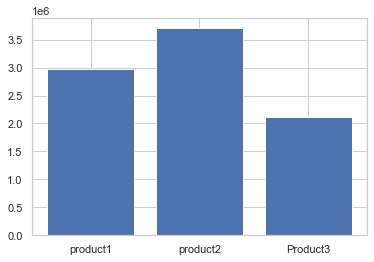

```python
import matplotlib.pyplot as plt
Product1Sales = df['Product_Category_1'].sum()
Product2Sales = df['Product_Category_2'].sum()
Product3Sales = df['Product_Category_3'].sum()
productSales = [Product1Sales,Product2Sales,Product3Sales]
plt.bar(['product1','product2','Product3'],productSales)
plt.show()
```

Here the product category 2 has the highest no. of sales among all the categories

Splitting the data based on cities

For city A, Sales of Each product is being compared

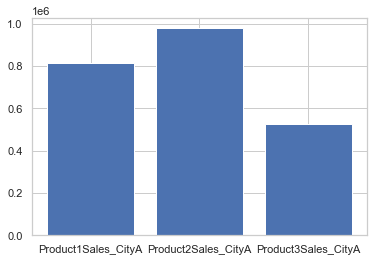

|  | User_ID | Product_ID | City_Category | Stay_In_Current_City_Years | Marital_Status | Product_Category_1 | Product_Category_2 | Product_Category_3 | Purchase | Gender | Age | Occupation | City_Code | State_Code | Zip_Code | City_Name | State |
| --- | --- | --- | --- | --- | --- | --- | --- | --- | --- | --- | --- | --- | --- | --- | --- | --- | --- |
| 0 | 1000001 | P00069042 | A | 2 | 0 | 3 | NaN | NaN | 8370 | F | 0-17 | 10 | C259 | S16 | 42420 | Henderson | Kentucky |
| 1 | 1000001 | P00248942 | A | 2 | 0 | 1 | 6.0 | 14.0 | 15200 | F | 0-17 | 10 | C259 | S16 | 42420 | Henderson | Kentucky |
| 2 | 1000001 | P00087842 | A | 2 | 0 | 12 | NaN | NaN | 1422 | F | 0-17 | 10 | C259 | S16 | 42420 | Henderson | Kentucky |
| 3 | 1000001 | P00085442 | A | 2 | 0 | 12 | 14.0 | NaN | 1057 | F | 0-17 | 10 | C259 | S16 | 42420 | Henderson | Kentucky |
| 5 | 1000003 | P00193542 | A | 3 | 0 | 1 | 2.0 | NaN | 15227 | M | 26-35 | 15 | C64 | S04 | 90036 | Los Angeles | California |
| ... | ... | ... | ... | ... | ... | ... | ... | ... | ... | ... | ... | ... | ... | ... | ... | ... | ... |
| 550026 | 1005975 | P00370853 | A | 1 | 0 | 19 | NaN | NaN | 62 | M | 26-35 | 14 | C64 | S04 | 90008 | Los Angeles | California |
| 550040 | 1005997 | P00370853 | A | 3 | 0 | 19 | NaN | NaN | 26 | F | 26-35 | 7 | C522 | S42 | 77036 | Houston | Texas |
| 550055 | 1006019 | P00372445 | A | 4+ | 0 | 20 | NaN | NaN | 238 | M | 26-35 | 0 | C91 | S04 | 94110 | San Francisco | California |
| 550058 | 1006024 | P00372445 | A | 0 | 1 | 20 | NaN | NaN | 121 | M | 26-35 | 12 | C489 | S41 | 37918 | Knoxville | Tennessee |
| 550062 | 1006032 | P00372445 | A | 3 | 0 | 20 | NaN | NaN | 473 | M | 46-50 | 7 | C60 | S04 | 90712 | Lakewood | California |

147720 rows × 17 columns

```python
cityA = df[df['City_Category'] == 'A']

purchaseA = cityA['Purchase'].sum()
Product1Sales_CityA = cityA['Product_Category_1'].sum()
Product2Sales_CityA = cityA['Product_Category_2'].sum()
Product3Sales_CityA = cityA['Product_Category_3'].sum()
ProductSales_cityA = [Product1Sales_CityA,Product2Sales_CityA,Product3Sales_CityA]
plt.bar(['Product1Sales_CityA','Product2Sales_CityA','Product3Sales_CityA'],ProductSales_cityA)
plt.show()
cityA
```

Some discount can be provided on product 3 to increase the sale

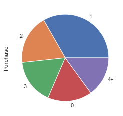

```python
dfs=cityA[['Stay_In_Current_City_Years','Purchase']]
dfs.groupby('Stay_In_Current_City_Years')['Purchase'].sum().sort_values(ascending=False).head(10).plot(kind='pie')
```

People who have Lived 1 year in city A Has the maximum Purchase Value and Those lived 4+ years has the least Purchase Value

Now the same analysis is being done for City B

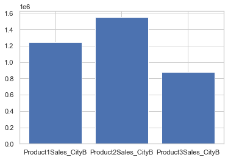

```python
cityB = df[df['City_Category'] == 'B']
purchaseB = cityB['Purchase'].sum()
Product1Sales_CityB = cityB['Product_Category_1'].sum()
Product2Sales_CityB = cityB['Product_Category_2'].sum()
Product3Sales_CityB = cityB['Product_Category_3'].sum()
ProductSales_cityB = [Product1Sales_CityB,Product2Sales_CityB,Product3Sales_CityB]
plt.bar(['Product1Sales_CityB','Product2Sales_CityB','Product3Sales_CityB'],ProductSales_cityB)
plt.show()
```

Here, for city B also, the product 2 sales are maximum

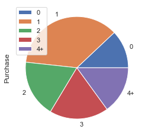

```python
cityB.groupby(['Stay_In_Current_City_Years']).sum().plot(kind ='pie',y = 'Purchase')
```

Here People who have lived less then 1 year close to 0 years have the least Purchase Value and Those lived Around ! year has the highest.

```
1663807476
```

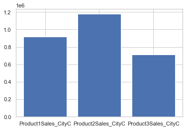

```python
cityC = df[df['City_Category'] == 'C']
purchaseC = cityC['Purchase'].sum()
print(purchaseC)
Product1Sales_CityC = cityC['Product_Category_1'].sum()
Product2Sales_CityC = cityC['Product_Category_2'].sum()
Product3Sales_CityC = cityC['Product_Category_3'].sum()
ProductSales_cityC = [Product1Sales_CityC,Product2Sales_CityC,Product3Sales_CityC]
plt.bar(['Product1Sales_CityC','Product2Sales_CityC','Product3Sales_CityC'],ProductSales_cityC)
plt.show()
```

For city C , The sales of Product 2 is the maximum

|  | User_ID | Product_ID | City_Category | Stay_In_Current_City_Years | Marital_Status | Product_Category_1 | Product_Category_2 | Product_Category_3 | Purchase | Gender | Age | Occupation | City_Code | State_Code | Zip_Code | City_Name | State |
| --- | --- | --- | --- | --- | --- | --- | --- | --- | --- | --- | --- | --- | --- | --- | --- | --- | --- |
| 4 | 1000002 | P00285442 | C | 4+ | 0 | 8 | NaN | NaN | 7969 | M | 55+ | 16 | C259 | S16 | 42420 | Henderson | Kentucky |
| 19 | 1000008 | P00249542 | C | 4+ | 1 | 1 | 5.0 | 15.0 | 19614 | M | 26-35 | 12 | C64 | S04 | 90032 | Los Angeles | California |
| 20 | 1000008 | P00220442 | C | 4+ | 1 | 5 | 14.0 | NaN | 8584 | M | 26-35 | 12 | C64 | S04 | 90032 | Los Angeles | California |
| 21 | 1000008 | P00156442 | C | 4+ | 1 | 8 | NaN | NaN | 9872 | M | 26-35 | 12 | C64 | S04 | 90032 | Los Angeles | California |
| 22 | 1000008 | P00213742 | C | 4+ | 1 | 8 | NaN | NaN | 9743 | M | 26-35 | 12 | C64 | S04 | 90032 | Los Angeles | California |
| ... | ... | ... | ... | ... | ... | ... | ... | ... | ... | ... | ... | ... | ... | ... | ... | ... | ... |
| 550057 | 1006023 | P00370853 | C | 2 | 1 | 19 | NaN | NaN | 61 | M | 26-35 | 0 | C489 | S41 | 37918 | Knoxville | Tennessee |
| 550060 | 1006026 | P00371644 | C | 1 | 1 | 20 | NaN | NaN | 494 | M | 36-45 | 6 | C489 | S41 | 37918 | Knoxville | Tennessee |
| 550061 | 1006029 | P00372445 | C | 1 | 1 | 20 | NaN | NaN | 599 | F | 26-35 | 1 | C338 | S36 | 97477 | Springfield | Oregon |
| 550064 | 1006035 | P00375436 | C | 3 | 0 | 20 | NaN | NaN | 371 | F | 26-35 | 1 | C64 | S04 | 90049 | Los Angeles | California |
| 550066 | 1006038 | P00375436 | C | 2 | 0 | 20 | NaN | NaN | 365 | F | 55+ | 1 | C235 | S20 | 1841 | Lawrence | Massachusetts |

171175 rows × 17 columns

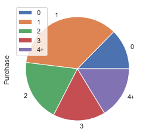

```python
cityC.groupby(['Stay_In_Current_City_Years']).sum().plot(kind ='pie',y = 'Purchase')
cityC
```

Here People who have lived less then 1 year close to 0 years have the least Purchase Value and Those lived Around ! year has the highest.

```python
purchase = [purchaseA,purchaseB,purchaseC]
```

Now, the Total purchase is compared for Each city

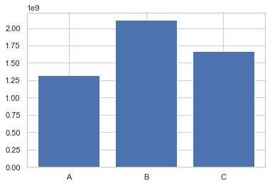

```python
plt.bar(['A','B','C'],purchase)
plt.show()
```

Total Purchase is Highest for City B and least for City A

```python
import os
import subprocess
import stat
import numpy as np
import seaborn as sns
from datetime import datetime
sns.set(style="white")
```

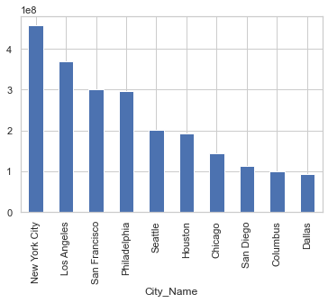

```python
dfs=df[['City_Name','Purchase']]
dfs.groupby('City_Name')['Purchase'].sum().sort_values(ascending=False).head(10).plot(kind='bar')
```

Here, The Top 10 city with The Maximum Purchase Value has been shown

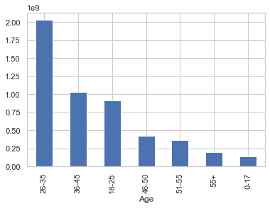

```python
dfs=df[['Age','Purchase']]
dfs.groupby('Age')['Purchase'].sum().sort_values(ascending=False).head(10).plot(kind='bar')
```

Here the Purchase Amount for different age groups has been compared. Age group 26-35 Has the highest Purchase Value and Age group 55+ and 0-17 has the least Purchase Value A personalised Discount can be provided to Them.

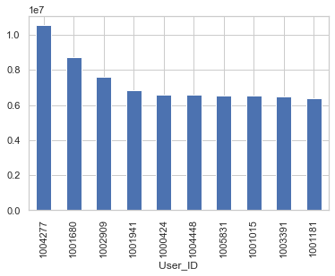

```python
dfs=df[['User_ID','Purchase']]
dfs.groupby('User_ID')['Purchase'].sum().sort_values(ascending=False).head(10).plot(kind='bar')
```

Here, The users with Highest Purchase Amount are shown. They can be given special Vouchers to keep them up.

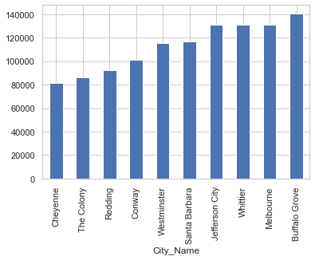

```python
dfs=df[['City_Name','Purchase']]
dfs.groupby('City_Name')['Purchase'].sum().sort_values(ascending=True).head(10).plot(kind='bar')
```

Here ten cities with least Purchase Values is shown

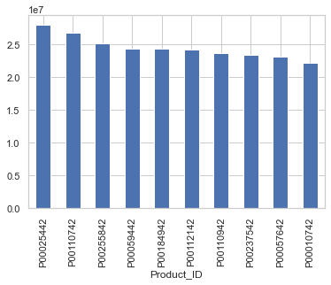

```python
dfs=df[['Product_ID','Purchase']]
dfs.groupby('Product_ID')['Purchase'].sum().sort_values(ascending=False).head(10).plot(kind='bar')
```

Products that are sold for the highest amount

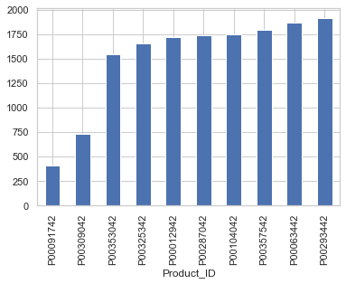

```python
dfs=df[['Product_ID','Purchase']]
dfs.groupby('Product_ID')['Purchase'].sum().sort_values(ascending=True).head(10).plot(kind='bar')
```

Products That are sold for the least Purchase amount

Special Discounts can be given on these products to increase sales